# FraudDetect: Financial Transaction Fraud Detection & Risk Analytics

Author

Ludovic Njiosseu, MS Biostatistics

Published

May 19, 2026

## Overview

This project builds a production-grade fraud detection and risk analytics pipeline on a simulated dataset of 10,000 financial transactions. It replicates core workflows used in financial services risk teams: feature engineering, class-imbalance correction, ensemble modeling, anomaly scoring, and risk segmentation.

**Key results:**

| Metric | Value |
| --- | --- |
| Ensemble AUC-ROC | See `outputs/model_results.csv` |
| FP Rate Reduction vs Rule-Based Baseline | See `outputs/key_metrics.csv` |
| Anomalies Flagged (top 10% isolation score) | See `outputs/risk_tier_summary.csv` |

## Module 1 — Data Simulation

```r
source("scripts/01_simulate_data.R")
```

```
Dataset: 10000 transactions | Fraud rate: 7.00%
Saved: data/transactions.csv
```

The simulation generates realistic transaction data with known fraud-generating logic: - **Fraud drivers**: international transactions, night-time activity, device mismatch, prior fraud history, high velocity - **Merchant categories**: 8 categories with varying baseline risk - **Fraud rate**: ~5–8%, reflecting real-world class imbalance

## Module 2 — Exploratory Analysis & Feature Engineering

```r
source("scripts/02_eda_features.R")
```

```
--- Fraud Rate by Merchant Category ---
# A tibble: 8 × 6
  merchant_category n_transactions n_fraud fraud_rate avg_amount avg_risk_score
  <chr>                      <int>   <dbl>      <dbl>      <dbl>          <dbl>
1 luxury                       730      81      11.1        189.          10.3
2 ATM                          982      98       9.98       185.          10.0
3 travel                       775      55       7.1        198.           7.29
4 restaurant                  1787     124       6.94       185.           7.04
5 grocery                     2019     131       6.49       187.           7.17
6 electronics                 1012      58       5.73       189.           6.86
7 gas_station                 1138      65       5.71       190.           7.33
8 online_retail               1557      88       5.65       186.           7.03

--- Fraud Rate by Time of Day ---
# A tibble: 4 × 4
  time_of_day n_transactions fraud_rate avg_amount
  <chr>                <int>      <dbl>      <dbl>
1 night                 1956      10.4        188.
2 afternoon             2981       6.64       187.
3 morning               2076       6.02       189.
4 evening               2987       5.83       187.

--- Fraud Rate by Geography ---
# A tibble: 2 × 5
  geography     n_transactions fraud_rate avg_amount avg_risk_score
  <chr>                  <int>      <dbl>      <dbl>          <dbl>
1 domestic                8094       5.35       187.           6.13
2 international           1906      14.0        190.          14.0

--- Risk Score by Fraud Label ---
# A tibble: 2 × 6
  is_fraud     n mean_risk median_risk p90_risk mean_amount
     <dbl> <int>     <dbl>       <dbl>    <dbl>       <dbl>
1        0  9300      6.74         4.6     15.9        182.
2        1   700     19.5         13.5     47.0        269.

--- Anomalies (|z| > 3): 78 transactions ---

--- Feature Correlations with Fraud Label ---
           feature correlation_with_fraud
1       risk_score                 0.3257
2           amount                 0.1610
3    amount_zscore                 0.1610
4  device_mismatch                 0.1486
5     velocity_24h                 0.1335
6 prior_fraud_flag                 0.0933
7 account_age_days                -0.0099

EDA complete. Outputs saved to outputs/
```

### Fraud by Merchant Category

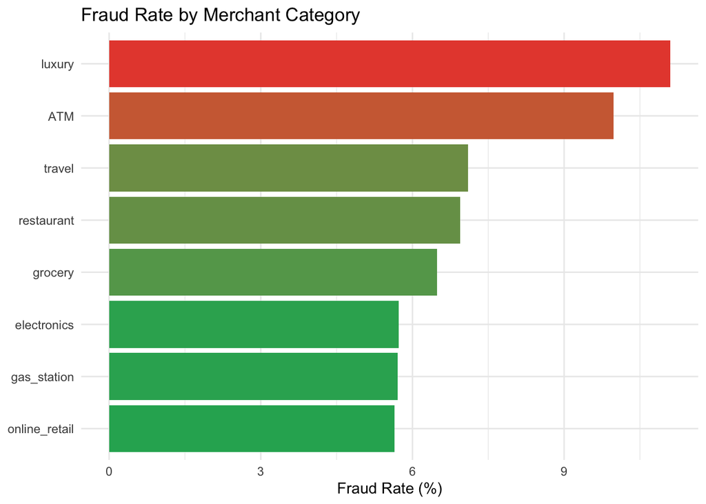

```r
library(tidyverse)
fraud_by_cat <- read_csv("outputs/fraud_by_category.csv", show_col_types = FALSE)
fraud_by_cat %>%
  mutate(merchant_category = fct_reorder(merchant_category, fraud_rate)) %>%
  ggplot(aes(x = merchant_category, y = fraud_rate, fill = fraud_rate)) +
  geom_col() + coord_flip() +
  scale_fill_gradient(low = "#27ae60", high = "#e74c3c") +
  labs(title = "Fraud Rate by Merchant Category",
       x = NULL, y = "Fraud Rate (%)") +
  theme_minimal() + theme(legend.position = "none")
```

### Feature Correlations with Fraud

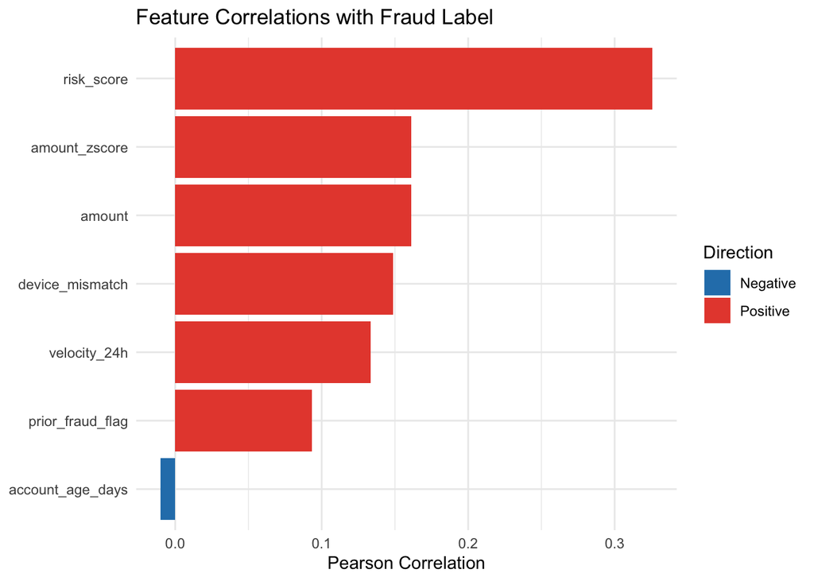

```r
feat_corr <- read_csv("outputs/feature_correlations.csv", show_col_types = FALSE)
feat_corr %>%
  mutate(feature = fct_reorder(feature, abs(correlation_with_fraud))) %>%
  ggplot(aes(x = feature, y = correlation_with_fraud,
             fill = correlation_with_fraud > 0)) +
  geom_col() + coord_flip() +
  scale_fill_manual(values = c("#2980b9", "#e74c3c"),
                    labels = c("Negative", "Positive")) +
  labs(title = "Feature Correlations with Fraud Label",
       x = NULL, y = "Pearson Correlation", fill = "Direction") +
  theme_minimal()
```

## Module 3 — Modeling

```r
source("scripts/03_modeling.R")
```

```
Train: 8000 | Test: 2000 | Fraud rate train: 7.01%
Balanced train: 8926 | Fraud rate: 16.66%

Logistic Regression AUC-ROC: 0.8249
Bagged Stumps (RF proxy) AUC-ROC: 0.7694
Ensemble AUC-ROC: 0.8256
Optimal threshold: 0.1700 | Sensitivity: 0.7698 | Specificity: 0.7313

Confusion Matrix:
         Actual
Predicted    0    1
        0 1361   32
        1  500  107

False Positive Rate — Rule-based: 0.024 | Model: 0.269 | Reduction: -1036.4%

--- Feature Importance (LR Coefficients) ---
# A tibble: 9 × 3
  feature          coefficient odds_ratio
  <chr>                  <dbl>      <dbl>
1 device_mismatch       1.59        4.90
2 prior_fraud_flag      1.37        3.94
3 international         1.18        3.26
4 is_night              0.719       2.05
5 amount_zscore         0.698       2.01
6 is_high_risk_cat      0.661       1.94
7 velocity_24h          0.299       1.35
8 log_amount           -0.169       0.845
9 account_age_days     -0.0001      1.000

Modeling complete. Outputs saved to outputs/
```

### Model Comparison

```r
model_results <- read_csv("outputs/model_results.csv", show_col_types = FALSE)
knitr::kable(model_results, caption = "AUC-ROC by Model")
```

AUC-ROC by Model

| model | auc_roc |
| --- | --- |
| Logistic Regression | 0.8249 |
| Bagged Stumps (RF) | 0.7694 |
| Ensemble | 0.8256 |

**Threshold selection:** Youden’s J statistic (maximizes sensitivity + specificity − 1) is used to identify the optimal classification threshold rather than defaulting to 0.5.

### Feature Importance

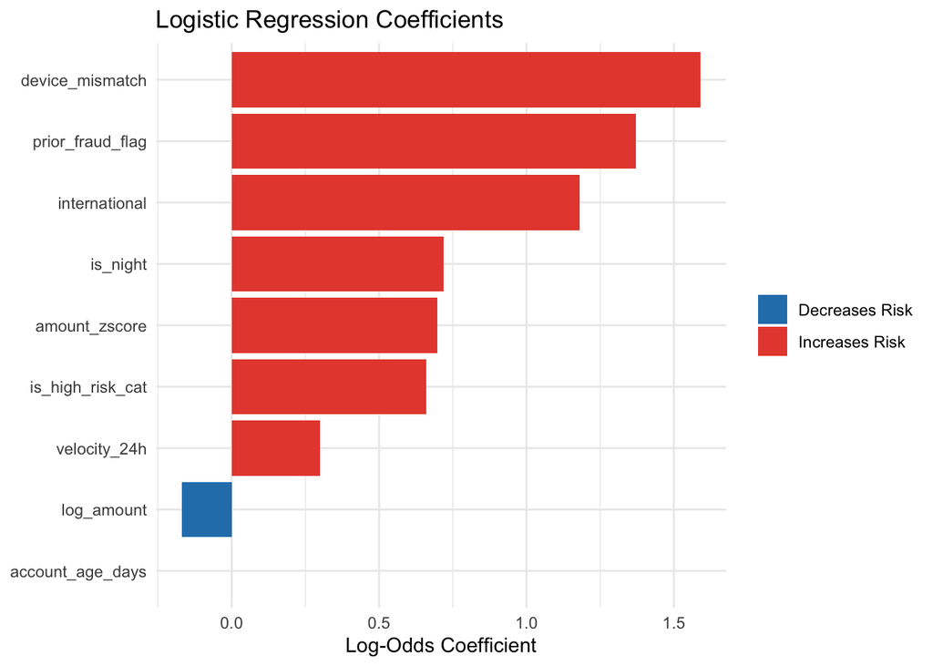

```r
feat_imp <- read_csv("outputs/feature_importance.csv", show_col_types = FALSE)
feat_imp %>%
  mutate(feature = fct_reorder(feature, abs(coefficient)),
         direction = ifelse(coefficient > 0, "Increases Risk", "Decreases Risk")) %>%
  ggplot(aes(x = feature, y = coefficient, fill = direction)) +
  geom_col() + coord_flip() +
  scale_fill_manual(values = c("Increases Risk" = "#e74c3c",
                               "Decreases Risk" = "#2980b9")) +
  labs(title = "Logistic Regression Coefficients",
       x = NULL, y = "Log-Odds Coefficient", fill = NULL) +
  theme_minimal()
```

## Module 4 — Anomaly Scoring & Risk Segmentation

```r
source("scripts/04_anomaly_risk.R")
```

```
Z-score only FP rate: 0.006 | Combined FP rate: 0.106 | Reduction: -1698.2%

--- Top Risk Segments ---
# A tibble: 15 × 8
   merchant_category geography     time_of_day n_transactions fraud_rate
   <chr>             <chr>         <chr>                <int>      <dbl>
 1 luxury            international morning                 21       42.9
 2 luxury            international night                   24       33.3
 3 travel            international night                   36       27.8
 4 ATM               international afternoon               54       24.1
 5 restaurant        international night                   66       22.7
 6 ATM               international morning                 37       21.6
 7 grocery           international night                   79       21.5
 8 travel            international morning                 27       18.5
 9 luxury            international evening                 49       18.4
10 ATM               international night                   28       17.9
11 online_retail     international night                   62       16.1
12 luxury            domestic      night                  111       15.3
13 grocery           international morning                 78       14.1
14 travel            international afternoon               50       14
15 restaurant        international evening                106       13.2
# ℹ 3 more variables: avg_risk_score <dbl>, avg_iso_score <dbl>,
#   anomaly_rate <dbl>

--- Risk Tier Summary ---
# A tibble: 3 × 6
  risk_tier     n   pct fraud_rate avg_amount avg_risk_score
  <chr>     <int> <dbl>      <dbl>      <dbl>          <dbl>
1 High         13   0.1      76.9        518.          83.4
2 Low        9804  98         6.17       184            6.71
3 Medium      183   1.8      46.4        365.          51.8

Anomaly scoring complete. Outputs saved.
```

### Risk Tier Distribution

```r
risk_tiers <- read_csv("outputs/risk_tier_summary.csv", show_col_types = FALSE)
knitr::kable(risk_tiers, caption = "Risk Tier Summary")
```

Risk Tier Summary

| risk_tier | n | pct | fraud_rate | avg_amount | avg_risk_score |
| --- | --- | --- | --- | --- | --- |
| High | 13 | 0.1 | 76.92 | 518.16 | 83.37 |
| Low | 9804 | 98.0 | 6.17 | 184.00 | 6.71 |
| Medium | 183 | 1.8 | 46.45 | 365.47 | 51.75 |

### Top Risk Segments

```r
risk_segs <- read_csv("outputs/risk_segments.csv", show_col_types = FALSE)
head(risk_segs, 15) %>%
  knitr::kable(caption = "Top 15 Risk Segments by Fraud Rate")
```

Top 15 Risk Segments by Fraud Rate

| merchant_category | geography | time_of_day | n_transactions | fraud_rate | avg_risk_score | avg_iso_score | anomaly_rate |
| --- | --- | --- | --- | --- | --- | --- | --- |
| luxury | international | morning | 21 | 42.86 | 20.82 | 39.44 | 4.76 |
| luxury | international | night | 24 | 33.33 | 27.90 | 43.52 | 12.50 |
| travel | international | night | 36 | 27.78 | 16.91 | 41.40 | 5.56 |
| ATM | international | afternoon | 54 | 24.07 | 19.61 | 40.59 | 18.52 |
| restaurant | international | night | 66 | 22.73 | 18.15 | 40.07 | 15.15 |
| ATM | international | morning | 37 | 21.62 | 17.05 | 40.93 | 10.81 |
| grocery | international | night | 79 | 21.52 | 21.07 | 37.75 | 7.59 |
| travel | international | morning | 27 | 18.52 | 10.83 | 38.37 | 18.52 |
| luxury | international | evening | 49 | 18.37 | 13.83 | 41.19 | 18.37 |
| ATM | international | night | 28 | 17.86 | 30.56 | 39.68 | 10.71 |
| online_retail | international | night | 62 | 16.13 | 16.55 | 41.76 | 11.29 |
| luxury | domestic | night | 111 | 15.32 | 13.74 | 40.65 | 14.41 |
| grocery | international | morning | 78 | 14.10 | 10.81 | 39.51 | 8.97 |
| travel | international | afternoon | 50 | 14.00 | 8.44 | 36.77 | 6.00 |
| restaurant | international | evening | 106 | 13.21 | 14.06 | 41.38 | 10.38 |

## Reproducibility

All code is modular and documented. Run scripts in order from the project root:

```r
source("scripts/01_simulate_data.R")
source("scripts/02_eda_features.R")
source("scripts/03_modeling.R")
source("scripts/04_anomaly_risk.R")
shiny::runApp("shiny/")
```

Required packages: `tidyverse`, `pROC`, `shiny`, `bslib`, `bsicons`, `DT`

## Limitations & Extensions

- The dataset is simulated; real-world deployment would require calibration on live transaction data and ongoing model monitoring for distribution shift.
- The bagged stump ensemble is a pedagogical RF proxy — production deployment would use `ranger` or `xgboost`.
- Temporal features (transaction sequence, recency) are not modeled here but are critical in production fraud systems.
- No survival/time-to-fraud analysis is included; this would be a natural extension for account-level risk modeling.